# Introducing Data Science with R

dsR

Shu-Kai Hsieh

# R 語言與資料科學導論

`資料科學家`的工作, 可以視為是一個探索、預測與解讀資料意義的互動歷程。而`語言分析`的工作, 在了解文本資料的語意與情緒表現上是重要的關鍵。本課程結合 了目前統計程式設計與自然語言處理技術, 以較為簡潔容易入門的設計與實際操作導引, 希望可以讓毫無相關程式學習基礎的學生在本課程的帶領下, 達到以下的學習目標:

- 瞭解 R 語言的基本知識。
- 瞭解結構與非結構性資料的特性與預處理工作, 特別是針對中文文本中呈現的語言特性的處理方法。
- 了解中文的語言特性與文本解析 (text analytics) 的基本概念。
- 選擇適當的變數與特徵並加以合理調製, 對之進行描述統計與視覺探勘, 針對不同的問題點與數據類型, 找出適當的圖形表達與統計分析。
- 學習簡易的自然語言處理與機器學習預測模式, 並應用在自己關心的領域。
- 學習實作資料科學專案與溝通表達。

## 課綱

詳細一點的版本

| Week | Date | Topic | Lab |
| --- | --- | --- | --- |
| 1 | 09/15 | 中秋節放假 |  |
| 2 | 09/22 | Introduction to Data Science and Text Analytics | Installing R and Rstudio |
| 3 | 09/29 | Introduction to Data Science and Text Analytics | data types and structures (vector) |
| 4 | 10/06 | Preparing / Obtaining Data | data structures (matrix, data frame, factor) |
| 5 | 10/13 | Scrubbing Data | list, Basic I/O |
| 6 | 10/20 | Exploratory data analysis and Graphics | control flow; writing functions |
| 7 | 10/27 | Exploratory data analysis and Graphics | data wrangling with dplyr and tidyr |
| 8 | 11/03 | Corpus and Natural Language Processing | data manipulation (with regex) |
| 9 | 11/10 | Corpus and Statistics | R and Statistics: [course one (five chapters)](https://www.datacamp.com/introduction-to-statistics) |
| 10 | 11/17 | Advanced Graphics |  |
| 11 | 11/24 | Machine Learning Basics |  |
| 12 | 12/01 | Classification and Clustering |  |
| 13 | 12/08 | **mini-Hackathon** |  |
| 14 | 12/15 | Discussion |  |
| 15 | 12/22 | Sentiment analysis |  |
| 16 | 12/29 | Reporting and Presenting Data | Web application with Shiny |
| 17 | 01/04 | Term project competition/presentation |  |
| 18 | 01/11 | **Final term project and report due** |  |

## 教練團

```
謝舒凱 <shukaihsieh@ntu.edu.tw>
林士凱 <vn512903@hotmail.com>
張瑜芸 <yuyun.unita@gmail.com>
黃資勻 <averocksanne@gmail.com>
李佳臻 <she767219@gmail.com>
吳小涵 <c04s84@gmail.com>
```

## 課程投影片

- Week 03
- Week 04
- Week 05

## 助教講義、習題與作業

[評分標準](http://lope.linguistics.ntu.edu.tw/courses/data_science/grading_policy2016.html)

- Week.3 : In-class exercise and homework / Rmd 檔
- Week.4 : In-class exercise and homework / Rmd 檔
- Week.5 : In-class exercise and homework

## 課程教材

在課程投影片中講解基本概念，如果有興趣了解進階內容，可參考以下線上教材

- [語言分析與資料科學](https://www.gitbook.com/book/loperntu/ladsbook/details)
- [開放語料庫：製程與分析](https://www.gitbook.com/book/loperntu/copens/details)

## 課程相關活動

- [NTU CEIBA](https://ceiba.ntu.edu.tw/1051LING5502)
- 課堂共筆
- 學習共筆
- [臉書社團](https://www.facebook.com/groups/652099794893097/)
- lopeR.Py 微課程

## 課程精神

1. 自主學習
2. 跨學門協作

## Capstone projects

- [分組名單](https://docs.google.com/document/d/14aWHW5dNykrC5uGbkq3dLk5wpbSYXQNMsirWVQI2oe0/edit?usp=sharing)

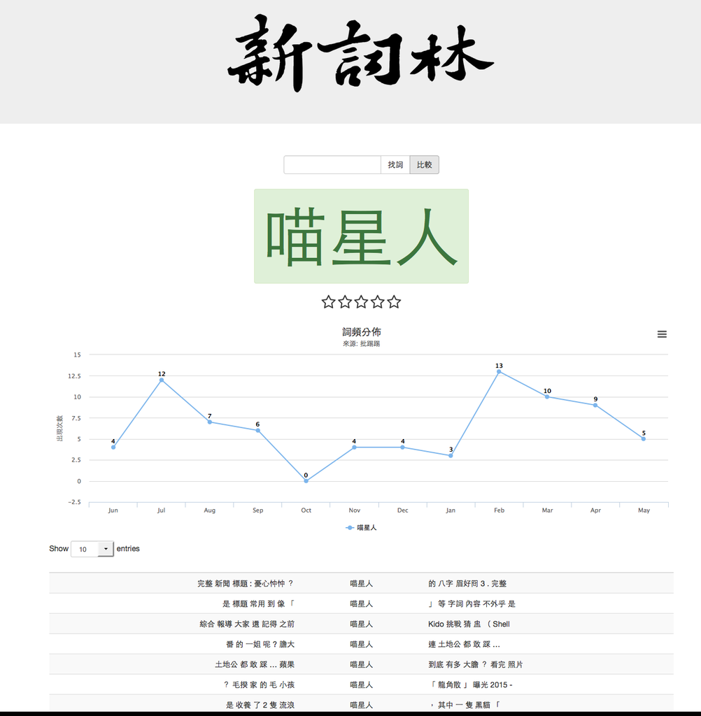